# Notes to Pablo for discussion

# N variants too high

El nombre de variants que hem predit és massa alt per ser normal. D’alguns gens obtinc fins a 20000 variants, de manera que es altament segur que tinc algun problema amb aquest tema.

Aqui una taula amb la distribució:

```r
nvariants.gene <- ab.tbl %>%
  group_by(keggid) %>%
  tally() %>%
  left_join(descriptions, by = 'keggid') %>%
  select(cycle, gene_name, n ) %>%
  arrange(cycle, gene_name, n)

gt::gt(nvariants.gene)
```

| cycle | gene_name | n |
| --- | --- | --- |
| carbon | chiA | 1 |
| carbon | coxL | 822 |
| carbon | pufM | 193 |
| carbon | rbcL I | 502 |
| nitrogen | amoA | 29 |
| nitrogen | hao | 10 |
| nitrogen | narB | 29 |
| nitrogen | nasA | 85 |
| nitrogen | nifH | 4 |
| nitrogen | ureC | 939 |
| phosporous | phnD | 3027 |
| phosporous | phnM | 5236 |
| phosporous | phoD | 14384 |
| phosporous | plcP | 368 |
| phosporous | ppk1 | 23653 |
| phosporous | ppx | 3987 |
| phosporous | pstS | 14665 |
| sulphur | dmdA | 422 |

### No reads recovered

He vist molt clarament com moltes d’elles deuen ser un artefacte perquè…no recuperen cap read! Aqui fico la taula amb la informació updated de quantes d’elles tenen com a abundancia un 0.

```r
counts.gene <- ab.raw %>%
  gather(key = 'sample', value = 'counts', -keggid, -genename) %>%
  group_by(genename,keggid) %>%
  summarize( total = sum(counts))


counts0 <- counts.gene %>%
  left_join(descriptions, by = 'keggid') %>%
  group_by( gene_name) %>%
  summarize( n = n(),
             n_0occ = sum(total == 0),
             n.morethan1 = n - n_0occ)

counts0 %>%
  gt::gt()
```

| gene_name | n | n_0occ | n.morethan1 |
| --- | --- | --- | --- |
| amoA | 29 | 1 | 28 |
| chiA | 1 | 0 | 1 |
| coxL | 822 | 22 | 800 |
| dmdA | 422 | 2 | 420 |
| hao | 10 | 2 | 8 |
| narB | 29 | 1 | 28 |
| nasA | 85 | 0 | 85 |
| nifH | 4 | 0 | 4 |
| phnD | 3027 | 814 | 2213 |
| phnM | 5236 | 2433 | 2803 |
| phoD | 14384 | 5687 | 8697 |
| plcP | 368 | 86 | 282 |
| ppk1 | 23653 | 11312 | 12341 |
| ppx | 3987 | 716 | 3271 |
| pstS | 14665 | 5563 | 9102 |
| pufM | 193 | 23 | 170 |
| rbcL I | 502 | 71 | 431 |
| ureC | 939 | 128 | 811 |

Perque existeixen aquestes variants? Probablement degut a que son chimeras? Amb la Marta SEbastian ho hem parlat i diu que potser es aquest l’origen. Aquests gens provenen de Assembly -> filtering > 1000 pb -> Gene prediction (prodigal + metagenemark).

Una altra opció es que aquests valors no n agafin cap conteig perque els contejos siguin ambigus en tots els casos. Pero no hauria de ser aixi?

### Related to prediction with MGM?

```r
counts.gene %>%
  mutate( origin = ifelse( str_detect(genename, 'mgm'), 'mgm', 'pro')) %>%
  left_join(descriptions, by = 'keggid') %>%
  group_by(origin) %>%
  summarize( n = n(),
             n_0occ = sum(total == 0),
             n.morethan1 = n - n_0occ,
             ratio = (n_0occ * 100) / n )
```

```
## # A tibble: 2 x 5
##   origin     n n_0occ n.morethan1 ratio
##   <chr>  <int>  <int>       <int> <dbl>
## 1 mgm    52553  20354       32199  38.7
## 2 pro    15803   6507        9296  41.2
```

No ho sembla pas a priori! Per tant el problema ha de provenir d’algun altre step.

### Related to gene length?

Mirant el gene lenght distribution vs counts dona alguna informació al respecte?

```r
library(seqinr)
```

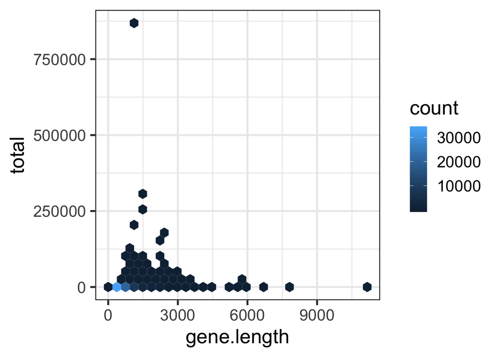

```r
fasta <- read.fasta(here('data/putative_genes', 'nuc_genes.fna'))

distribution <- tibble(genename =  names(fasta),
                       gene.length = getLength(fasta)) %>%
  mutate(origin = ifelse( str_detect(genename, 'mgm'), 'mgmark', 'prodigal'))

counts.gene  %>%
  left_join(distribution, by = 'genename') %>%
  ggplot( aes( x = gene.length, y = total)) +
  geom_hex()
```

No hi ha cap relació aparent, cool.

## Proposal annotation

Ara mateix, per ser més conservatiu, havia pensat the following steps:

- Annotacio inicial amb KOFAM. Em permet filtrar rapid una part gran del dataset, i per la majoria dels gens tinc el HMM. El mètode tindrà hipotèticament FP pero no te perque (per exemple per dmdA no n’he trobat cap).
- Dels gens que tingui un COG de confiança, anotació de COG.
  - Nomes em quedo amb els que tinguin KOFAM + COG al 70% identitat i que els hits resultants siguin tots del mateix COG. Amb aixo soc força conservador al meu veure.
- Els gens sense anotació perquè no tinc ni COG ni KEGG ni res, simplement faig un BLAST amb la database d’elecció i sóc molt restrictiu.

FIN

# SCG problems ?

Alguns dels gens que tenies com a definits per fer el ratio analysis se’n van molt, o presenten una distribucio molt diferents als altres.

Jo els vaig treure…

També et vaig desobeir i vaig fer l’anotació amb els KOFAM per poder-ho comparar :)

I els he anotat amb KEGGs, de manera que existeix la possiblitat de que hagi fet algun error. Ara això segurament ho canvii afegint l’anotació per COGs, i quedantme amb els resultats d’una manera diferent Anyway, tu per Malaspina tenies algun resultat similar? O no?

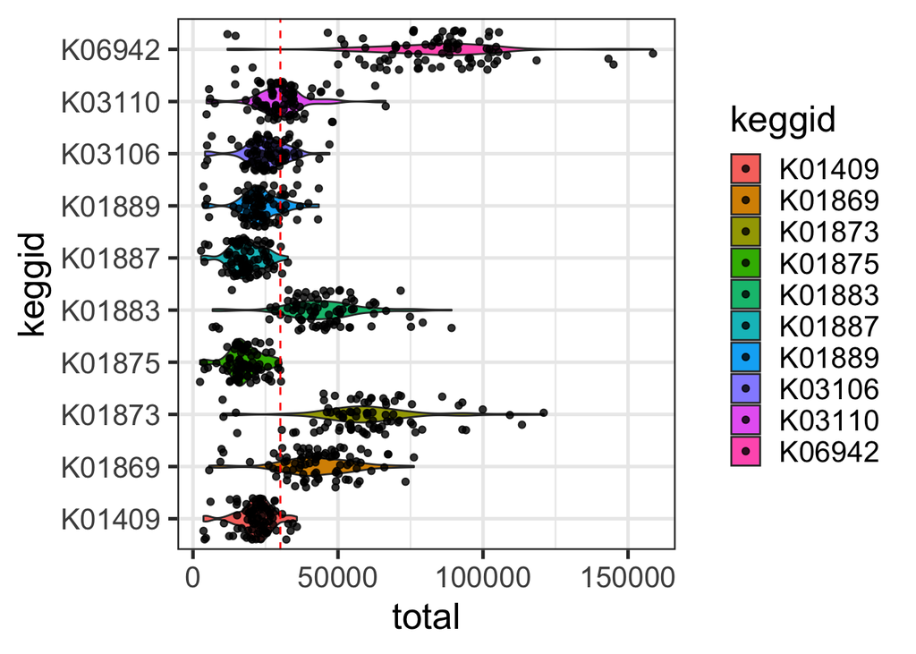

```r
scg.raw <- read_rds(here('data/04_table_gen/','lengthnorm.tbl.rds')) %>%
  filter(keggid %in% scg)

sctotals <- scg.raw %>%
  filter( keggid %in% scg) %>%
  gather( key = 'sample', value = 'normcount', -genename, -keggid)

sctotals %>%
  group_by(keggid, sample) %>%
  summarize( total = sum(normcount)) %>%
  ggplot( aes( keggid, total, fill = keggid)) +
  geom_violin() +
  geom_jitter(alpha = 0.8) +
  geom_hline(yintercept = 30123.3, color = 'red', linetype = 2) +
  coord_flip()
```

```r
counts.scg <- scg.raw %>%
  gather(key = 'sample', value = 'counts', -keggid, -genename) %>%
  group_by(genename,keggid) %>%
  summarize( total = sum(counts))


counts0 <- counts.scg %>%
  group_by( keggid) %>%
  summarize( n = n(),
             n_0occ = sum(total == 0),
             n.morethan1 = n - n_0occ)

counts0 %>%
  gt::gt()
```

| keggid | n | n_0occ | n.morethan1 |
| --- | --- | --- | --- |
| K01409 | 63374 | 34137 | 29237 |
| K01869 | 19499 | 5464 | 14035 |
| K01873 | 5907 | 826 | 5081 |
| K01875 | 54782 | 29728 | 25054 |
| K01883 | 6364 | 953 | 5411 |
| K01887 | 62170 | 32458 | 29712 |
| K01889 | 41914 | 20118 | 21796 |
| K03106 | 7419 | 1368 | 6051 |
| K03110 | 7806 | 1971 | 5835 |
| K06942 | 1575 | 15 | 1560 |

Is there other genes ?